# Associations between RBP expression and miRNA activity

Gabrielle Perron

2026-September-25

# 1 Load libraries

```r
library(here)
library(tidyverse)
library(scater)
library(SingleCellExperiment)
library(scales)
library(data.table)
library(ppcor)
```

# 2 Load the TCGA gene expression data (log2RSEM) obtained from Firebrowse

```r
logRSEM_data <- list.files(here("data"), pattern = "log2RSEM.csv", full.names = TRUE) |>
  lapply(fread) |>
  lapply(as.data.frame) |>
  lapply(function(x) {
    rownames(x) <- x[[1]]
    x[-1]
  })

head(logRSEM_data[[1]][, 1:5])
```

```
##       TCGA-2F-A9KO-01 TCGA-2F-A9KP-01 TCGA-2F-A9KQ-01 TCGA-2F-A9KR-01
## A1BG        4.8845735        3.736973        4.344828        4.724421
## A1CF      -13.2877124      -13.287712      -13.287712      -13.287712
## A2BP1       0.8068602      -13.287712      -13.287712      -13.287712
## A2LD1       6.7403286        6.280747        5.868600        5.180144
## A2ML1       7.8800034        6.718159        5.946258       11.164587
## A2M        13.2011773       12.814224       13.102688       11.919534
##       TCGA-2F-A9KT-01
## A1BG         3.927678
## A1CF       -13.287712
## A2BP1        2.177089
## A2LD1        5.810500
## A2ML1        8.371823
## A2M         10.870501
```

# 3 Define the genes of interest for the t-SNE plots

```r
gene_names_tSNE <- c("DDX55", "PTBP1", "SUPV3L1")
```

# 4 Normalize gene expression tables by subtracting the average of normal samples and filter for the genes of interest and for tumor samples

```r
log2FC_gois <- lapply(logRSEM_data, function(x) {
  # Skip datasets without normal samples (ending in -11)
  if (!any(grepl("-11$", colnames(x)))) {
    return(NA)
  }

  # Filter to genes of interest
  x <- x[rownames(x) %in% gene_names_tSNE, ]

  # Subtract mean of normal samples from all samples
  normal_cols <- grepl("-11$", colnames(x))
  row_means_normal <- rowMeans(x[, normal_cols])
  x <- sweep(x, 1, row_means_normal, "-")

  # Transpose and keep only tumor samples (ending in -01)
  x <- t(x)
  as.data.frame(x[grepl("-01$", rownames(x)), ])
})

head(log2FC_gois[[2]])
```

```
##                       DDX55     PTBP1     SUPV3L1
## TCGA-3C-AAAU-01 -0.01236171 0.9600269 -0.41776947
## TCGA-3C-AALI-01  0.08265214 0.9321302 -0.82023195
## TCGA-3C-AALJ-01  1.12882637 1.1600331  1.17020183
## TCGA-3C-AALK-01  0.22743645 0.9923247 -0.55766122
## TCGA-4H-AAAK-01  0.38414852 0.6163452 -0.14166175
## TCGA-5L-AAT0-01 -0.03986924 0.7585924 -0.09605869
```

# 5 Extract cancer types and combine data

```r
# Extract cancer type from file paths
logRSEM_files <- list.files(here("data"), pattern = "log2RSEM.csv", full.names = TRUE)
cancer_types <- str_extract(logRSEM_files, "[A-Z]+(?=_log2RSEM)")

# Combine data from all cancers into a long-format data frame
log2FC_gois_all <- log2FC_gois |>
  imap_dfr(
    ~ if (is.data.frame(.x)) {
      tibble::rownames_to_column(.x, "sample") |>
        mutate(cancer = cancer_types[.y], .before = 1)
    }
  ) |>
  mutate(sample = str_replace_all(sample, "-", "."))
```

# 6 Load the miRNA activity data and filter for tumors

```r
miR_act <- read.csv(here("TCGA", "output", "supplementary_tables", "TCGA_miRNA_activity.csv"))
miR_act <- miR_act[miR_act$sample_type == "tumor", ]
```

# 7 Visualization of pan-cancer RBP expression using t-SNE plots

The t-SNE embedding of pan-cancer miRNA activity was already computed and plotted for miR-17-5p, miR-29-3p, and miR-19-3p in `09_TCGA_miRNA_activity.Rmd`, which caches the resulting `SingleCellExperiment` to `TCGA/output/rds/sce_tSNE.rds`. Here we reuse that same embedding (`reducedDim(sce_tSNE, "TSNE")`) and colour it by RBP expression instead of recomputing the t-SNE.

```r
sce_tSNE <- readRDS(here("TCGA", "output", "rds", "sce_tSNE.rds"))
sce_tSNE
```

```
## class: SingleCellExperiment
## dim: 91 3162
## metadata(0):
## assays(1): logcounts
## rownames(91): let-7-5p miR-101-3p ... miR-615-3p miR-874-3p
## rowData names(0):
## colnames(3162): TCGA.2F.A9KO.01 TCGA.2F.A9KP.01 ... TCGA.QS.A744.01
##   TCGA.SJ.A6ZI.01
## colData names(8): sample cancer ... miR-200bc-3p miR-122-5p
## reducedDimNames(2): pca TSNE
## mainExpName: NULL
## altExpNames(0):
```

Merge selected RBP expression log2FC values into the t-SNE object

```r
rbp_expr <- log2FC_gois_all |>
  dplyr::select(sample, all_of(gene_names_tSNE))

coldata_tsne <- as.data.frame(colData(sce_tSNE)) |>
  left_join(rbp_expr, by = "sample")

colData(sce_tSNE)[gene_names_tSNE] <- coldata_tsne[gene_names_tSNE]
```

Theme function for t-SNE plots

```r
custom_theme_plot <- function(size_text = 15,
                               leg_pos = "right",
                               size_text_titles = NULL,
                               classic = TRUE,
                               line_size = 0.85,
                               line_size_color = "black",
                               axis_ticks_length = 0.25,
                               axis_ticks_color = "black",
                               size_legend_text = 12,
                               size_legend_title = 14) {
  if (is.null(size_text_titles)) {
    size_text_titles <- size_text + 2
  }
  gg.plots <- if (classic) theme_classic() else theme_bw()
  gg.plots +
    theme(
      axis.text.x = element_text(size = size_text, angle = 45, hjust = 1, color = line_size_color),
      axis.line = element_line(size = line_size, colour = line_size_color),
      axis.ticks = element_line(colour = axis_ticks_color, size = line_size),
      axis.ticks.length = unit(axis_ticks_length, "cm"),
      axis.title.x = element_text(size = size_text_titles),
      legend.position = leg_pos,
      plot.title = element_text(hjust = 0.5, size = size_text),
      axis.text.y = element_text(size = size_text, color = "black"),
      axis.title.y = element_text(size = size_text_titles),
      legend.text = element_text(size = size_legend_text),
      legend.title = element_text(size = size_legend_title),
      legend.key.size = unit(0.8, "cm")
    )
}
```

Helper function to create a t-SNE plot colored by RBP expression

```r
rbp_tsne_plot <- function(gene, sce_obj, limits = 1) {
  plotReducedDim(sce_obj,
                 ncomponents = 2,
                 dimred = "TSNE",
                 point_size = 2,
                 colour_by = gene) +
    custom_theme_plot(size_text = 27, size_text_titles = 30, size_legend_text = 21, size_legend_title = 24) +
    scale_colour_gradient2(
      low = "blue", high = "red", mid = "white",
      midpoint = 0, limits = c(-limits, limits),
      oob = scales::squish,
      name = paste0(gene, " expression\nlog2FC(RSEM T vs avg N)")
    ) +
    theme(legend.key.size = unit(1.2, "cm"))
}
```

Plot t-SNE for each RBP, coloured by expression log2FC(tumor vs average normal)

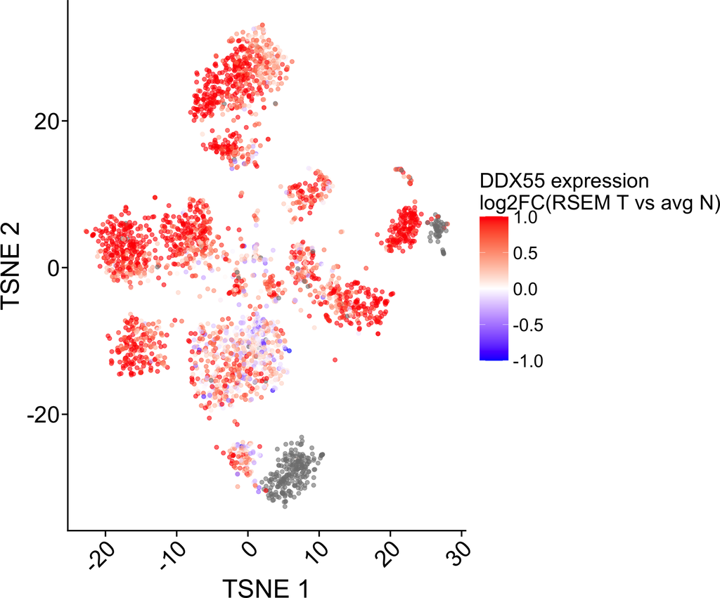

```
## Saved: TCGA_DDX55_expr_tSNE.pdf
```

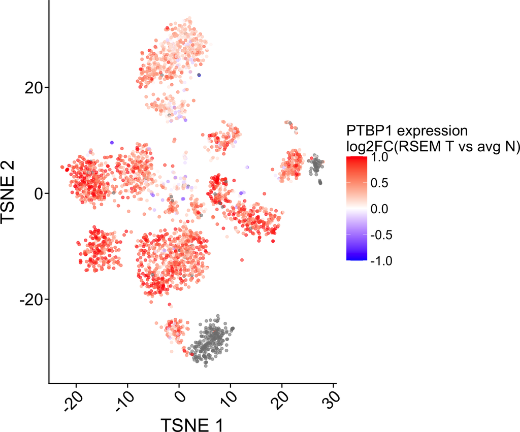

```
## Saved: TCGA_PTBP1_expr_tSNE.pdf
```

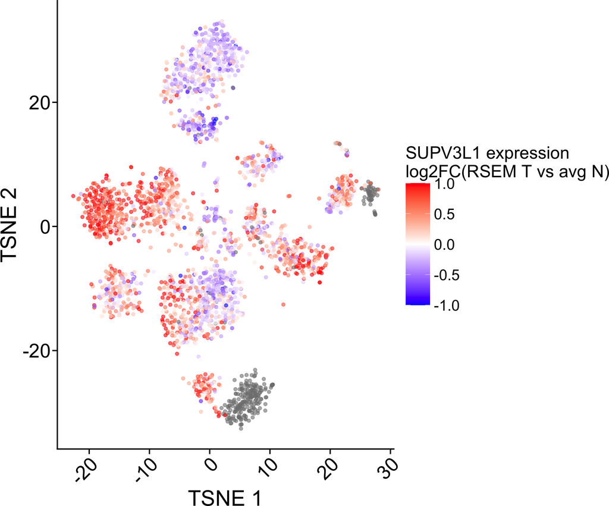

```
## Saved: TCGA_SUPV3L1_expr_tSNE.pdf
```

```r
rbp_lims <- 1

rbp_pdf_names <- setNames(
  paste0("TCGA_", gene_names_tSNE, "_expr_tSNE.pdf"),
  gene_names_tSNE
)

for (gene in gene_names_tSNE) {
  print(rbp_tsne_plot(gene, sce_tSNE, limits = rbp_lims))

  pdf_file <- here("TCGA", "output", "figures", rbp_pdf_names[[gene]])
  pdf(pdf_file, height = 10, width = 12.5)
  print(rbp_tsne_plot(gene, sce_tSNE, limits = rbp_lims))
  dev.off()

  cat("Saved:", rbp_pdf_names[[gene]], "\n")
}
```